# Anxiety Disorder

S670 Fall 2023

Dataset link: https://www.kaggle.com/datasets/amirhoseinmousavian/mental-health

Factors affecting mental health: 1. GDP 2. Age 3. Gender 4. Treatment distribution

```r
# Loading the datasets
#setwd("C:/Users/Acer/Desktop/R markdown")
gdp_df <- read_csv('data/anxiety-disorders-prevalence-vs-gdp.csv' , show_col_types = FALSE)
income_class <- read_csv('data/income_classification.csv', show_col_types = FALSE)


age_df <- read.csv("data/anxiety-disorders-prevalence-by-age.csv", sep= ,)
country <- read_xlsx("data/countries_and_classification.xlsx")


gender_df <- read.csv("data/anxiety-disorders-prevalence-males-vs-females.csv")
```

```r
#filtering data from year 1990 to 2019.
gdp_df <- subset(gdp_df, Year >= 1990 & Year <= 2019)
age_df <- subset(age_df, Year >= 1990 & Year <= 2019)
gender_df <- subset(gender_df, Year >= 1990 & Year <= 2019)
```

```r
#cleaning the gdp df
gdp_df <-
  rename(gdp_df,
    "Anxiety_disorders" = "Anxiety disorders (share of population) - Sex: Both - Age: Age-standardized",
    "GDP_per_capita" = "GDP per capita, PPP (constant 2017 international $)",
    "Population" = "Population (historical estimates)"
  )

# There are lot of unfilled rows in the code column.fill that up
unique_entity_codes_continents <- unique(gdp_df[, c("Entity", "Code", "Continent")])
cleaned_entity_codes_continents <- na.omit(unique_entity_codes_continents)
```

```r
cleaned_entity_codes_continents
```

```
## # A tibble: 285 × 3
##    Entity                Code     Continent
##    <chr>                 <chr>    <chr>
##  1 Abkhazia              OWID_ABK Asia
##  2 Afghanistan           AFG      Asia
##  3 Akrotiri and Dhekelia OWID_AKD Asia
##  4 Aland Islands         ALA      Europe
##  5 Albania               ALB      Europe
##  6 Algeria               DZA      Africa
##  7 American Samoa        ASM      Oceania
##  8 Andorra               AND      Europe
##  9 Angola                AGO      Africa
## 10 Anguilla              AIA      North America
## # ℹ 275 more rows
```

```r
#clean the age df
age_df$Anxiety.disorders..share.of.population....Sex..Both...Age..All.ages <- NULL
age_df$Anxiety.disorders..share.of.population....Sex..Both...Age..Age.standardized <- NULL
```

```r
#rename columns
age_df <- age_df %>%
  rename(
    `Age_05-14` = `Anxiety.disorders..share.of.population....Sex..Both...Age..5.14.years`,
    `Age_15-19` = `Anxiety.disorders..share.of.population....Sex..Both...Age..15.19.years`,
    `Age_20-24` = `Anxiety.disorders..share.of.population....Sex..Both...Age..20.24.years`,
    `Age_25-29` = `Anxiety.disorders..share.of.population....Sex..Both...Age..25.29.years`,
    `Age_30-34` = `Anxiety.disorders..share.of.population....Sex..Both...Age..30.34.years`,
    `Age_35-39` = `Anxiety.disorders..share.of.population....Sex..Both...Age..35.39.years`,
    `Age_40-44` = `Anxiety.disorders..share.of.population....Sex..Both...Age..40.44.years`,
    `Age_45-49` = `Anxiety.disorders..share.of.population....Sex..Both...Age..45.49.years`,
    `Age_50-54` = `Anxiety.disorders..share.of.population....Sex..Both...Age..50.54.years`,
    `Age_55-59` = `Anxiety.disorders..share.of.population....Sex..Both...Age..55.59.years`,
    `Age_60-64` = `Anxiety.disorders..share.of.population....Sex..Both...Age..60.64.years`,
    `Age_65-69` = `Anxiety.disorders..share.of.population....Sex..Both...Age..65.69.years`,
    `Age_70+` = `Anxiety.disorders..share.of.population....Sex..Both...Age..70..years`
  )
```

```r
#making new age categories
age_df$Age_05_19 <- rowMeans(age_df[, c('Age_05-14', 'Age_15-19')], na.rm = TRUE)
age_df$Age_20_39 <- rowMeans(age_df[, c('Age_20-24','Age_25-29', 'Age_30-34', 'Age_35-39' )], na.rm = TRUE)
age_df$Age_40_59 <- rowMeans(age_df[, c('Age_40-44','Age_45-49','Age_50-54','Age_55-59')], na.rm = TRUE)
age_df$Age_60_ <- rowMeans(age_df[, c('Age_60-64', 'Age_65-69', 'Age_70+')], na.rm = TRUE)
```

```r
#creating a new df with the new categories
age_df <- dplyr::select(age_df, -"Age_05-14",-"Age_15-19",-"Age_20-24",-"Age_25-29", -"Age_30-34", -"Age_35-39", -"Age_40-44", -"Age_45-49", -"Age_50-54", -"Age_55-59", -"Age_60-64", -"Age_65-69",-"Age_70+")
```

```r
#gender dataframe
gender_df <-
  rename(gender_df,
    "Male_anxiety" = "Anxiety.disorders..share.of.population....Sex..Male...Age..All.ages",
    "Female_anxiety" = "Anxiety.disorders..share.of.population....Sex..Female...Age..Age.standardized",
    "Population" = "Population..historical.estimates."
  )
```

```r
#combine the income calssification with the gdp df
countries_df <- country[, c("Code", "Classification")]
gdp_merged <- merge(gdp_df, countries_df, by = "Code")
#Filtering the datasets as required for modelling
gdp_new <- dplyr::select(gdp_merged, -Continent, -Code)
gdp_new <- na.omit(gdp_new)
```

```r
#combine the gender df with the income classification
gender_new <- dplyr::select(gender_df, -Continent, -Code, -Population)
gender_new <- gender_new[complete.cases(gender_new$Male_anxiety, gender_new$Female_anxiety), ]
```

merge the data of gdp and age

```r
merged_1 <- merge(gdp_new, age_df, by = c("Entity", "Year"))
```

merge gender df and gdp and age

```r
merge_2 <- merge(merged_1, gender_new, by= c("Entity", "Year"))
```

create a correlation matrix

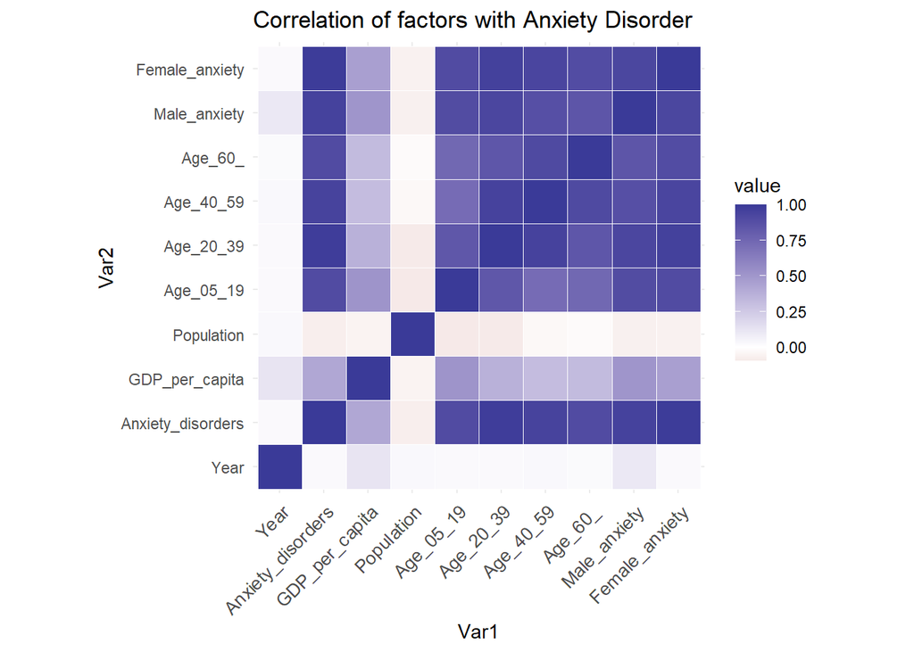

```r
numeric_data <- merge_2[sapply(merge_2, is.numeric)]

#calculate the correlation matrix
cor_matrix <- cor(numeric_data)

#melt the correlation matrix into a long format
cor_melted <- reshape2::melt(cor_matrix)


ggplot(cor_melted, aes(Var1, Var2, fill = value)) +
  geom_tile(color = "white") +
  scale_fill_gradient2() +
  theme_minimal() +
  labs(title = "Correlation of factors with Anxiety Disorder") +
  theme(axis.text.x = element_text(angle = 45, vjust = 1, size = 10, hjust = 1)) +
  coord_fixed()
```

> 1.GDP

```r
gdp_yearlyMean <- gdp_df %>%
  filter(!Entity %in% c("World", "Upper-middle-income countries", "High-income countries", "Low-income countries","Lower-middle-income countries", "Middle-income countries")) %>%
  group_by(Year) %>%
  summarise(Mean_anxiety = mean(Anxiety_disorders, na.rm = TRUE))
```

plot of anxiety over time

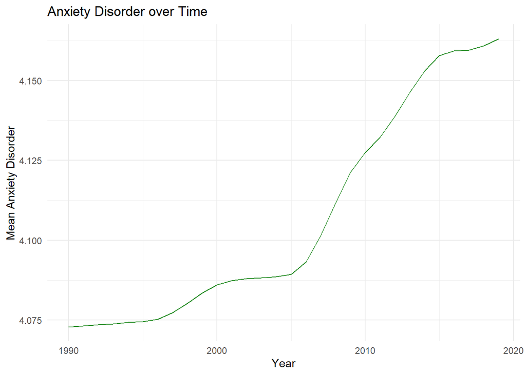

```r
ggplot(gdp_yearlyMean, aes(x = Year, y = Mean_anxiety)) +
  geom_line(color = "forestgreen") +
  labs(title = "Anxiety Disorder over Time" , y = "Mean Anxiety Disorder")+
  theme_minimal()
```

GDP vs Anxiety Disorder (1990-2019)

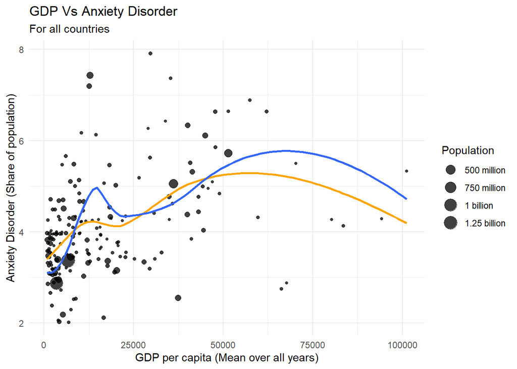

```r
gdp_2 <- gdp_df %>%
  filter(!Entity %in% c("World", "Upper-middle-income countries", "High-income countries", "Low-income countries","Lower-middle-income countries", "Middle-income countries")) %>%
  group_by(Entity) %>%
  summarise(Mean_anxiety = mean(Anxiety_disorders, na.rm = TRUE), Mean_gdp = mean(GDP_per_capita, na.rm = TRUE), Mean_pop = mean(Population, na.rm = TRUE) )
gdp_2 <- na.omit(gdp_2)

# Create breaks for Mean_pop
mean_pop_breaks <- c(5.00e+08, 7.50e+08, 1.00e+09, 1.25e+09)

# Create labels for the breaks
mean_pop_labels <- c("500 million", "750 million", "1 billion", "1.25 billion")

# Plot using ggplot2
ggplot(gdp_2, aes(x = Mean_gdp, y = Mean_anxiety)) +
  geom_point(aes(size = Mean_pop), alpha = 0.75) +
  geom_smooth(method = "loess", se = FALSE, color = "orange") +  # unweighted
  geom_smooth(method = "loess", aes(weight = Mean_pop), se = FALSE) +
  labs(title = "GDP Vs Anxiety Disorder",
       x = "GDP per capita (Mean over all years)",
       y = "Anxiety Disorder (Share of population)",
       subtitle = "For all countries") +
  scale_size(name = "Population",
                        breaks = mean_pop_breaks,
                        labels = mean_pop_labels)+
  theme_minimal()
```

1990 & 2019 GDP vs Anxiety Disorder

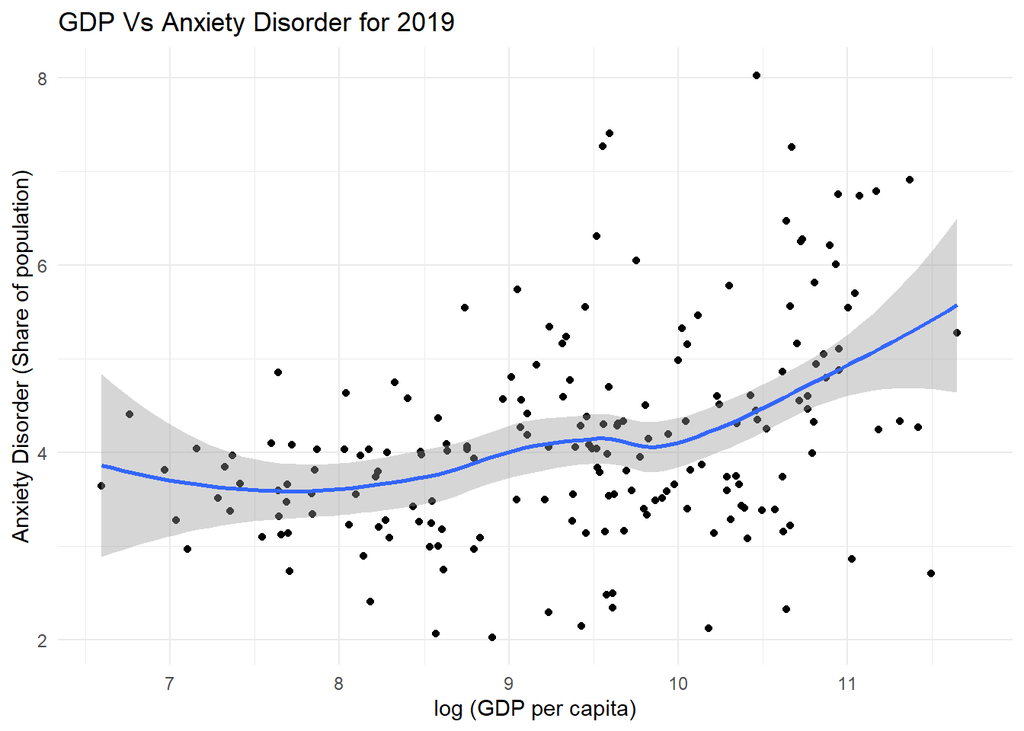

```r
gdp_df |>
  filter(Year == 2019, !Entity %in% c("World", "Upper-middle-income countries", "High-income countries", "Low-income countries","Lower-middle-income countries", "Middle-income countries")) |>
  ggplot(aes(x = log(GDP_per_capita), y = Anxiety_disorders)) +
  geom_point() +
  geom_smooth(method = "loess" ) +
  labs(title = "GDP Vs Anxiety Disorder for 2019" , y = "Anxiety Disorder (Share of population)", x= "log (GDP per capita)")+
  theme_minimal()
```

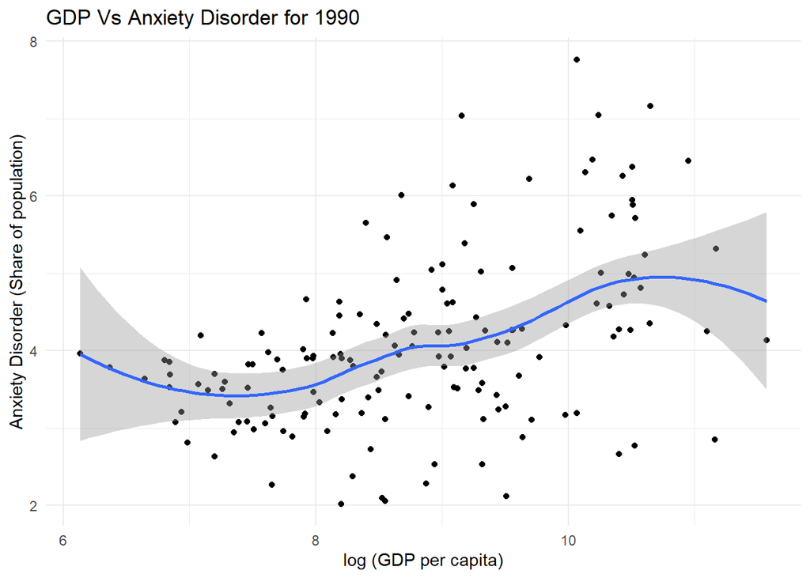

```r
gdp_df |>
  filter(Year == 1990, !Entity %in% c("World", "Upper-middle-income countries", "High-income countries", "Low-income countries","Lower-middle-income countries", "Middle-income countries")) |>
  ggplot(aes(x = log(GDP_per_capita), y = Anxiety_disorders)) +
  geom_point() +
  geom_smooth(method = "loess" ) +
  labs(title = "GDP Vs Anxiety Disorder for 1990" , y = "Anxiety Disorder (Share of population)", x= "log (GDP per capita)" )+
  theme_minimal()
```

By observing the 1990 and 2019 trends of log GDP vs the Anxiety disorder, the trend seems that with increase in gdp , there is increase in anxiety. But the data points are way too scattered. So, let’s consider other factors like population, income of a country, gender , age.

2019 log Population vs Anxiety Disorder.

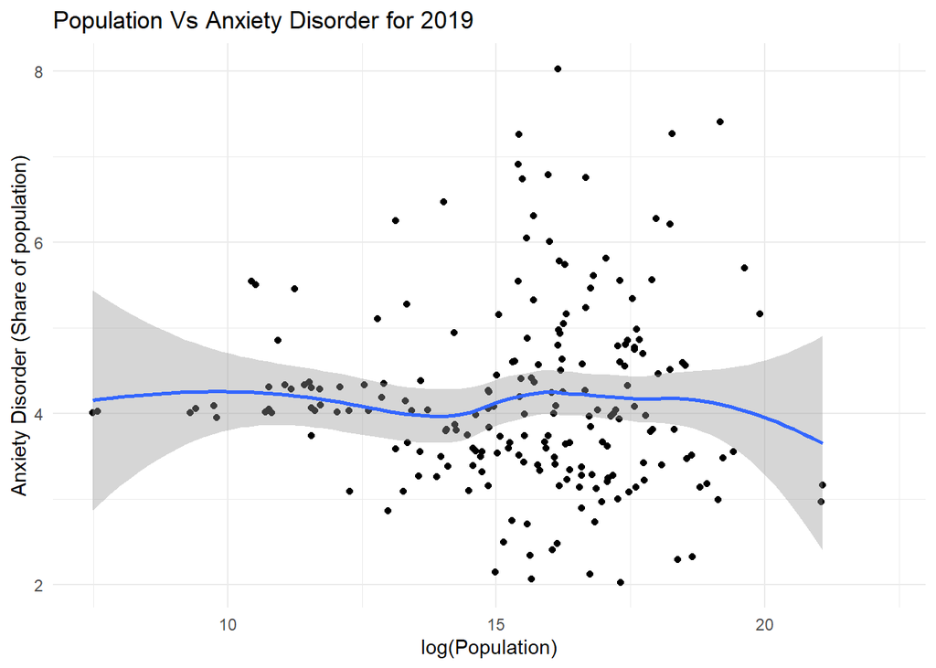

```r
gdp_df |>
  filter(Year == 2019, !Entity %in% c("World", "Upper-middle-income countries", "High-income countries", "Low-income countries","Lower-middle-income countries", "Middle-income countries")) |>
  ggplot(aes(x = log(Population), y = Anxiety_disorders)) +
  geom_point() +
  geom_smooth(method = "loess" ) +
  labs(title = "Population Vs Anxiety Disorder for 2019" , y = "Anxiety Disorder (Share of population)")+
  theme_minimal()
```

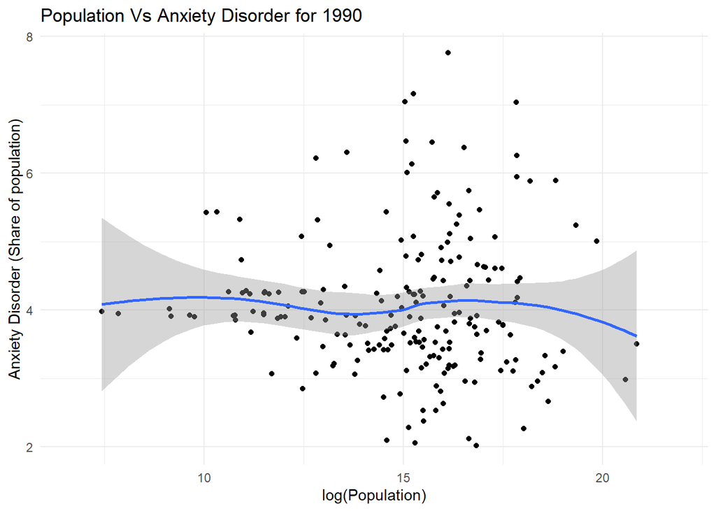

```r
gdp_df |>
  filter(Year == 1990, !Entity %in% c("World", "Upper-middle-income countries", "High-income countries", "Low-income countries","Lower-middle-income countries", "Middle-income countries")) |>
  ggplot(aes(x = log(Population), y = Anxiety_disorders)) +
  geom_point() +
  geom_smooth(method = "loess" ) +
  labs(title = "Population Vs Anxiety Disorder for 1990" , y = "Anxiety Disorder (Share of population)")+
  theme_minimal()
```

log population does not seem to have a major effect on the anxiety levels.

cleaning the gdp df

```r
merged_data <- merge(gdp_df, cleaned_entity_codes_continents, by = "Entity", all.x = TRUE)

#check duplicate columns
merged_data$Code <- ifelse(is.na(merged_data$Code.x), merged_data$Code.y, merged_data$Code.x)
merged_data$Continent <- ifelse(is.na(merged_data$Continent.x), merged_data$Continent.y, merged_data$Continent.x)

#drop unecessary columns
merged_data$Code.x <- NULL
merged_data$Code.y <- NULL
merged_data$Continent.x <- NULL
merged_data$Continent.y <- NULL
```

merging the income classification

```r
#merging based on the 'Code' column
final_data <- merge(merged_data, income_class, by = "Code", all.x = TRUE)
final_data <- na.omit(final_data)
```

```r
#count the number of rows for each entity
entity_counts <- table(final_data$Entity)

#filter entities with exactly 30 years of data
complete_data_entities <- names(entity_counts[entity_counts == 30])

num_complete_data_entities <- length(complete_data_entities)
print(num_complete_data_entities)
```

```
## [1] 157
```

We have the data of about 157 countries when we combine the income classification with the original data.

```r
#filter final_data to include only entities with complete data
final_data_complete_years <- final_data[final_data$Entity %in% complete_data_entities, ]
```

```r
final_data_complete_years$Entity <- NULL
```

```r
#unique combinations of Country and Income Classification
unique_countries_classifications <- unique(final_data_complete_years[, c("Code", "Classification")])

#number of unique countries for each income classification
unique_income_classification_counts <- table(unique_countries_classifications$Classification)

#counts
print(unique_income_classification_counts)
```

```
##
##         High income          Low income Lower middle income Upper middle income
##                  45                  21                  44                  47
```

filter out some countries (8) from the main dataframe

```r
countries <- c("United States", "Spain", "China", "Argentina", "India", "Bhutan", "Madagascar", "Ethiopia")
final_data_complete_years <- final_data_complete_years |> filter(Country %in% countries)
```

```r
income_unique <- unique(final_data_complete_years[,c("Country", "Classification")])
custom_order <- c("High income", "Upper middle income", "Lower middle income", "Low income")
income_unique$Classification <- factor(income_unique$Classification, levels = custom_order)
income_unique <- income_unique[order(income_unique$Classification), ]

print(income_unique)
```

```
##           Country      Classification
## 91          Spain         High income
## 211 United States         High income
## 1       Argentina Upper middle income
## 61          China Upper middle income
## 31         Bhutan Lower middle income
## 151         India Lower middle income
## 121      Ethiopia          Low income
## 181    Madagascar          Low income
```

anxiety disorder over years

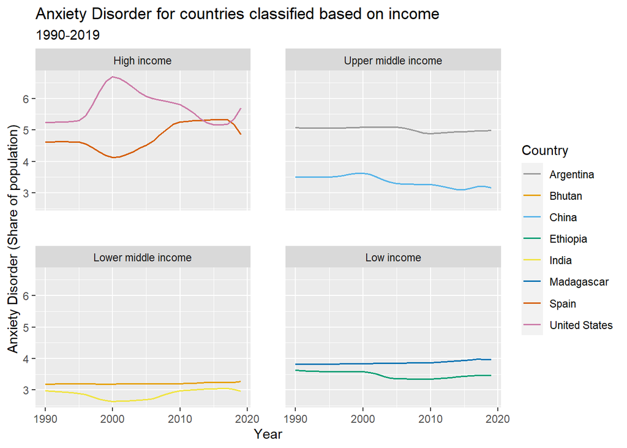

```r
final_data_complete_years$Classification <- factor(final_data_complete_years$Classification, levels = c("High income", "Upper middle income", "Lower middle income","Low income"))

ggplot(final_data_complete_years, aes(x= Year, y = Anxiety_disorders, color = Country)) +
  geom_line(size = 0.6)+
  facet_wrap(~ Classification)+
  theme(panel.spacing = unit(1, "cm", data = NULL)) +
  scale_color_manual(values = cb_palette) +
  labs(title = "Anxiety Disorder for countries classified based on income" , subtitle = "1990-2019", y = "Anxiety Disorder (Share of population)")
```

Anxiety vs log (GDP)

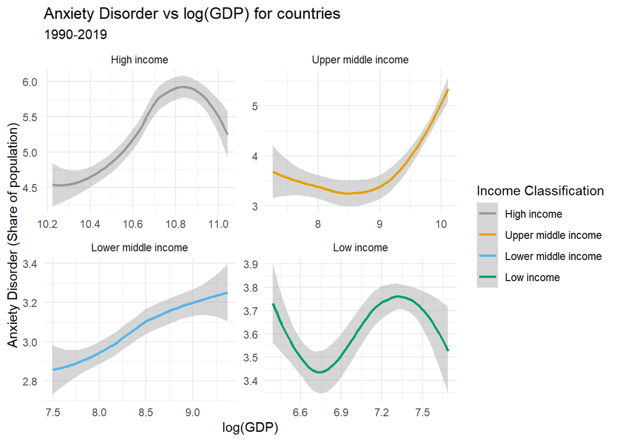

```r
ggplot(final_data_complete_years, aes(x= log(GDP_per_capita), y = Anxiety_disorders, color = Classification)) +
  geom_smooth(method = "loess", span = 1.0)+
  facet_wrap(~ Classification, scales = "free")+
  theme(panel.spacing = unit(1, "cm", data = NULL)) +
  scale_color_manual(values = cb_palette) +
  labs(title = "Anxiety Disorder vs log(GDP) for countries" , subtitle = "1990-2019", y = "Anxiety Disorder (Share of population)",
       x = "log(GDP)", color ="Income Classification")+
  theme_minimal()
```

For the middle income countries we see that with increase in log gdp, anxiety increases, whereas the high income sees an unsual dip for very high gdp.

> 2. AGE

```r
age_df_long <- age_df %>%
  pivot_longer(
    cols = starts_with("Age"),
    names_to = "age",
    values_to = "prevalence"
  )
```

```r
age_df_final <- country %>% left_join( age_df_long, by=c('Code'))
```

```r
age_df_final$Classification <- factor(age_df_final$Classification, levels = c("High income", "Upper middle income", "Lower middle income","Low income"))
```

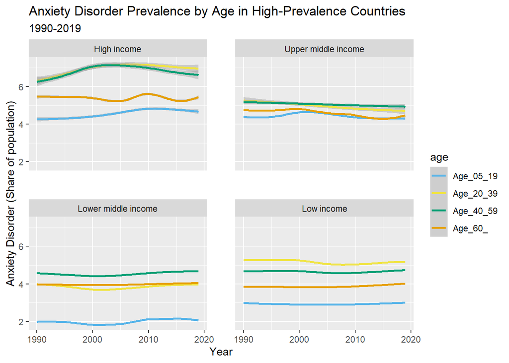

```r
countries <- c("United States", "Spain", "China", "Argentina", "India", "Bhutan", "Madagascar", "Ethiopia")

age_df_final |>
  filter(Country %in% countries) |>

  ggplot(aes(x = Year.y, y = prevalence, color = age)) +
  geom_smooth() +
  facet_wrap(~ Classification)+
  scale_color_manual(values = c( "#56B4E9", "#F0E442","#009E73","#E69F00" )) +
  theme(panel.spacing = unit(1, "cm", data = NULL)) +
  labs(title = "Anxiety Disorder Prevalence by Age in High-Prevalence Countries",
       subtitle = "1990-2019" ,
       x = "Year",
       y = "Anxiety Disorder (Share of population)")
```

Overall, the working population is most affected by anxiety.

> 3. GENDER

```r
countries_df <- country[, c("Code", "Classification")]
gender_merged <- merge(gender_df, countries_df, by = "Code")
```

```r
#filtering the dataset by taking only the required countries under consideration
countries <- c("United States", "Spain", "China", "Argentina", "India", "Bhutan", "Madagascar", "Ethiopia")
gender_filter <- gender_merged[gender_merged$Entity %in% countries, ]

gender_filter <- subset(gender_filter, Year> 1989 & Year<2020)
gender_filter<- distinct(gender_filter)
```

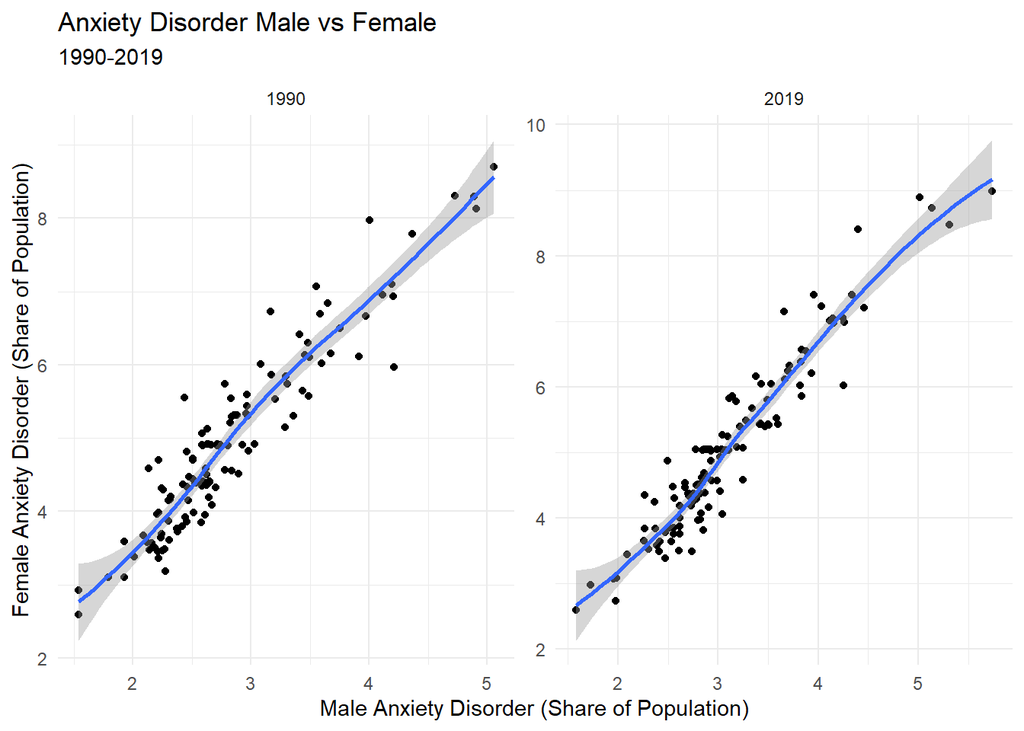

```r
gender_df |>
  filter(Year == c(2019, 1990), Entity!= c("World", "Upper-middle-income countries", "High-income countries", "Low-income countries","Lower-middle-income countries", "Middle-income countries")) |>
  ggplot(aes(x = Male_anxiety, y = Female_anxiety)) +
  geom_point() +
  geom_smooth()+
  facet_wrap(~Year, scale = "free")+
  labs(title = "Anxiety Disorder Male vs Female", subtitle = "1990-2019" ,
       x = "Male Anxiety Disorder (Share of Population)",
       y = "Female Anxiety Disorder (Share of Population)")+
  theme_minimal()
```

We can observe that the anxiety is much more higher in females as compared to males. The slope of the curve greater than 1.

```r
#calculating mean share of population for each country (grouping by countries)
mean_values_g <- gender_filter %>%
  group_by(Entity, Classification) %>%
  summarise(Mean_Male = mean(Male_anxiety, na.rm = TRUE), Mean_Female = mean(Female_anxiety, na.rm = TRUE))
```

mean anxiety over the 3 decades for countries

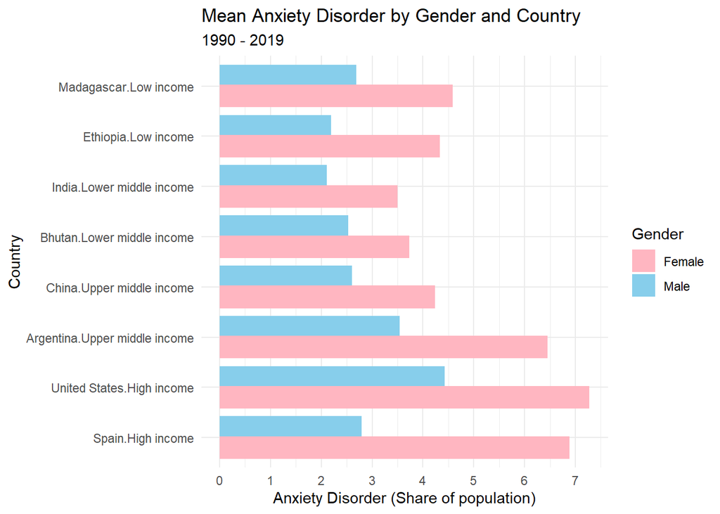

```r
# Reshaping the data to long format
melted_data <- mean_values_g %>%
  gather(key = "Gender", value = "Mean_Value", -Entity, -Classification)

# Define the desired order for the "Classification" levels
classification_order <- c("High income", "Upper middle income", "Lower middle income", "Low income")

melted_data$Classification <- factor(melted_data$Classification, levels = c("High income", "Upper middle income", "Lower middle income","Low income"))

# Convert "Classification" to a factor with the desired order within the ggplot aes mapping
ggplot(melted_data, aes(y = interaction(Entity, Classification), x = Mean_Value, fill = Gender, order = reorder(Classification, -match(Classification, classification_order)))) +
  geom_bar(stat = "identity", position = position_dodge(width = 0.8)) +
  labs(title = "Mean Anxiety Disorder by Gender and Country", subtitle = "1990 - 2019",
       y = "Country",
       x = "Anxiety Disorder (Share of population)") +
  scale_fill_manual(values = c("Mean_Male" =  "skyblue", "Mean_Female" =  "lightpink"),
                    labels = c("Mean_Female" = "Female", "Mean_Male" = "Male")) +
  theme_minimal()+
  scale_x_continuous(breaks = seq(0, 7, by = 1))
```

- Considering mean of anxiety for the years 1990-2019, for all the categories of countries based on income, we observe that the anxiety disorder levels are significantly higher in females as compared to males.

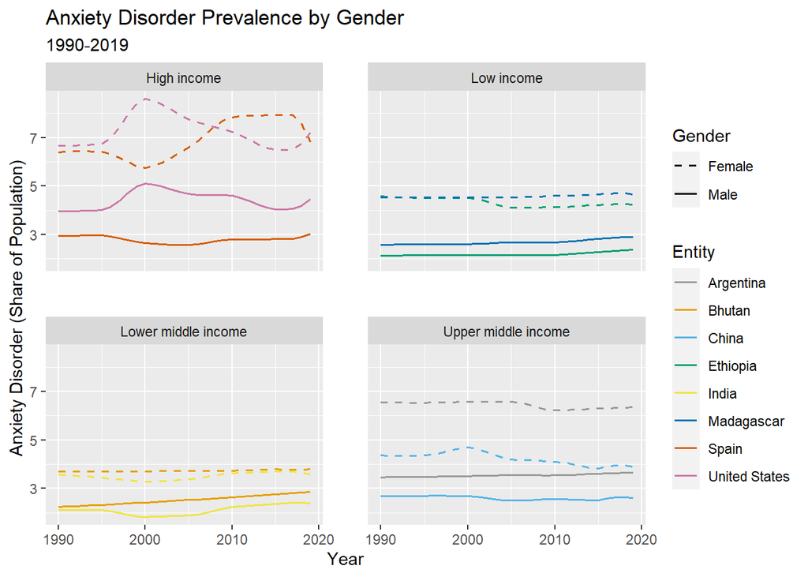

```r
# For both males and females

# Create a new dataframe combining male and female data
combined_data <- rbind(
  transform(gender_filter, Gender = "Male", Anxiety_Value = Male_anxiety),
  transform(gender_filter, Gender = "Female", Anxiety_Value = Female_anxiety)
)

# Plot for males and females on the same graph
ggplot(combined_data, aes(x = Year, y = Anxiety_Value, color = Entity, linetype = Gender)) +
  geom_line(size = 0.6) +
  #facet_wrap(~Entity, scales = "free") +
  labs(title = "Anxiety Disorder Prevalence by Gender",
       subtitle = "1990-2019" ,
       x = "Year",
       y = "Anxiety Disorder (Share of Population)") +
  scale_color_manual(values = cb_palette) +
  theme(panel.spacing = unit(1, "cm", data = NULL)) +
  scale_linetype_manual(values = c("Male" = "solid", "Female" = "dashed"))+
  facet_wrap(~Classification)
```

Females higher than males.

> 4. Treatment of anxiety disorder.
- We have the percent of the population of a country for which out of the population with anxiety disorder how many had potential adequate treatment, other treatments and were left untreated.
- Plot these stats for countries differentiated by income.

```r
setwd("C:/Users/Acer/Desktop/R markdown")
treatment.df <- read.csv('data/anxiety-disorders-treatment-gap.csv')
```

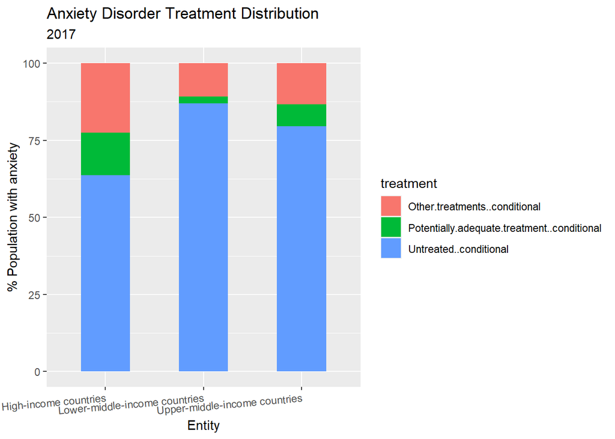

```r
#plot for high income -countries and lower-middle income, and upper middle income countries

treatment.df |>

  filter(Entity %in% c('High-income countries', 'Upper-middle-income countries' , 'Lower-middle-income countries')) |>

  pivot_longer(
    cols = c("Potentially.adequate.treatment..conditional", "Other.treatments..conditional", "Untreated..conditional"),
    names_to = "treatment",
    values_to = "percent"
  ) |>

  ggplot(aes(y = percent, x = Entity , fill = treatment))  +
  geom_bar(stat = "identity", width = 0.5) +
  labs(title = 'Anxiety Disorder Treatment Distribution' ,
       subtitle = '2017' , y = "% Population with anxiety") +
  scale_color_manual(values = cb_palette) +
  theme(axis.text.x = element_text(angle = 5, hjust = 1))
```

Across all the categories,we can see that the majority of the population is untreated, this is a great cause of concern. For the high income countries, the share of population receiving treatments is higher as compared to other middle-low income countries. (it has better facilities).

> 5. Age when first had anxiety depression.

```r
setwd("C:/Users/Acer/Desktop/R markdown")
first.df <- read.csv('data/age-when-first-had-anxiety-depression.csv')
```

```r
#colnames(first.df)
first.df <- rename( first.df ,
    "Age 0-13" = Share...Question..mh7b_2...Age.range.when.first.felt.anxious.depressed...Answer..Ages..13...Gender..all...Age_group..all,
    "Age 13-19" = Share...Question..mh7b_2...Age.range.when.first.felt.anxious.depressed...Answer..Ages.13.19...Gender..all...Age_group..all ,
    "Age 20-29" = Share...Question..mh7b_2...Age.range.when.first.felt.anxious.depressed...Answer..Ages.20.29...Gender..all...Age_group..all ,
    "Age 30-39" = Share...Question..mh7b_2...Age.range.when.first.felt.anxious.depressed...Answer..Ages.30.39...Gender..all...Age_group..all ,
    "Age>40" = Share...Question..mh7b_2...Age.range.when.first.felt.anxious.depressed...Answer..Ages..40...Gender..all...Age_group..all ,
    "Refused to tell" = Share...Question..mh7b_2...Age.range.when.first.felt.anxious.depressed...Answer..Don.t.know.Refused...Gender..all...Age_group..all
  )
```

```r
#converting to longer format
df_long <- pivot_longer(first.df ,
                      cols = c("Age 0-13" , "Age 13-19", "Age 20-29" , "Age 30-39" , "Age>40",                      "Refused to tell"),
                      names_to = "Age_Group",
                      values_to = "Percent")
```

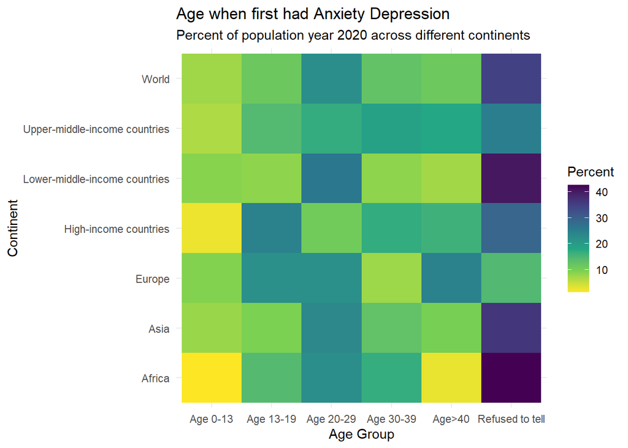

```r
#rectangular distribution
ggplot(df_long, aes( x = Age_Group , y = Entity, fill = Percent)) +
  geom_tile() +
  labs(title="Age when first had Anxiety Depression", subtitle = 'Percent of population year 2020 across different continents' , x = "Age Group", y = "Continent") +
  scale_fill_viridis_c(direction = -1) +
  theme_minimal()
```

A major chunk of population refuses to tell when they first experienced anxiety. Across the teenage years, high income countries have a high percent of population first experiencing anxiety, As we progress towards 20-29 age group Lower middle income countries, Europe, Asia , Africa see a significant rise too. We can say that the major chunk of population first experiences anxiety before the age of 30, although many people have refused to reveal the age.

###Fitting a Model

```r
model_lo <- gam(Anxiety_disorders ~ s(log(GDP_per_capita)) + Year ,weights = Population, data = merge_2 )

#summary of the model
summary(model_lo)
```

```
##
## Family: gaussian
## Link function: identity
##
## Formula:
## Anxiety_disorders ~ s(log(GDP_per_capita)) + Year
##
## Parametric coefficients:
##               Estimate Std. Error t value Pr(>|t|)
## (Intercept) 51.0637460  0.7007939   72.87   <2e-16 ***
## Year        -0.0235176  0.0003494  -67.31   <2e-16 ***
## ---
## Signif. codes:  0 '***' 0.001 '**' 0.01 '*' 0.05 '.' 0.1 ' ' 1
##
## Approximate significance of smooth terms:
##                          edf Ref.df    F p-value
## s(log(GDP_per_capita)) 8.998      9 8878  <2e-16 ***
## ---
## Signif. codes:  0 '***' 0.001 '**' 0.01 '*' 0.05 '.' 0.1 ' ' 1
##
## R-sq.(adj) =  0.356   Deviance explained = 36.1%
## GCV = 3.8345e+07  Scale est. = 3.8342e+07  n = 141300
```

```r
#predictions using the model
predictions <- predict(model_lo, newdata = merge_2)

#nse
mse <- mean((predictions - merge_2$Anxiety_disorders)^2)
cat("Mean Squared Error (MSE):", mse, "\n")
```

```
## Mean Squared Error (MSE): 1.171253
```

```r
#rmse
rmse <- sqrt(mse)
cat("Root Mean Squared Error (RMSE):", rmse, "\n")
```

```
## Root Mean Squared Error (RMSE): 1.082245
```

```r
#R-squared
rsquared <- cor(predictions, merge_2$Anxiety_disorders)^2
cat("R-squared:", rsquared, "\n")
```

```
## R-squared: 0.1926601
```

```r
library(mgcv)
model1 <- gam(Anxiety_disorders ~ s(log(GDP_per_capita)) + s(Year) , data = merge_2 )

#summary of the model
summary(model1)
```

```
##
## Family: gaussian
## Link function: identity
##
## Formula:
## Anxiety_disorders ~ s(log(GDP_per_capita)) + s(Year)
##
## Parametric coefficients:
##             Estimate Std. Error t value Pr(>|t|)
## (Intercept) 4.100497   0.002629    1560   <2e-16 ***
## ---
## Signif. codes:  0 '***' 0.001 '**' 0.01 '*' 0.05 '.' 0.1 ' ' 1
##
## Approximate significance of smooth terms:
##                          edf Ref.df       F p-value
## s(log(GDP_per_capita)) 8.973  9.000 5702.47  <2e-16 ***
## s(Year)                3.539  4.386   53.66  <2e-16 ***
## ---
## Signif. codes:  0 '***' 0.001 '**' 0.01 '*' 0.05 '.' 0.1 ' ' 1
##
## R-sq.(adj) =  0.267   Deviance explained = 26.7%
## GCV = 0.97684  Scale est. = 0.97674   n = 141300
```

```r
#predictions using the model
predictions <- predict(model1, newdata = merge_2)

#nse
mse <- mean((predictions - merge_2$Anxiety_disorders)^2)
cat("Mean Squared Error (MSE):", mse, "\n")
```

```
## Mean Squared Error (MSE): 0.9766514
```

```r
#rmse
rmse <- sqrt(mse)
cat("Root Mean Squared Error (RMSE):", rmse, "\n")
```

```
## Root Mean Squared Error (RMSE): 0.9882567
```

```r
#R-squared
rsquared <- cor(predictions, merge_2$Anxiety_disorders)^2
cat("R-squared:", rsquared, "\n")
```

```
## R-squared: 0.2669074
```

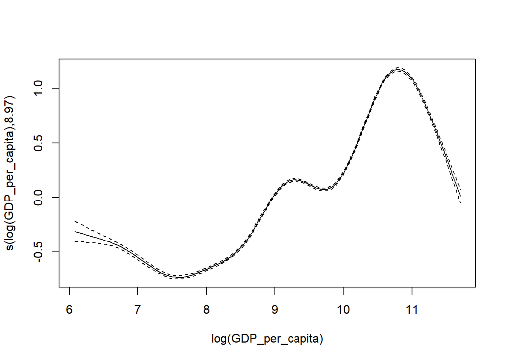

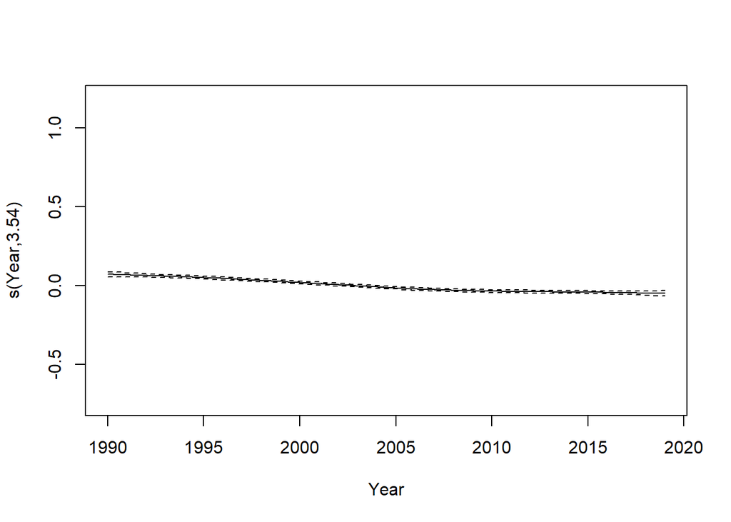

```r
plot(model1)
```

The model has a r2 of 0.26 which may seem low, but considering the variability in the predictability factors of anxiety, it seems pretty decent.

modeling female anxiety

```r
model_female <- gam(Female_anxiety ~ s(log(GDP_per_capita)) + s(Year) , data = merge_2 )

# Print the summary of the model
summary(model_female)
```

```
##
## Family: gaussian
## Link function: identity
##
## Formula:
## Female_anxiety ~ s(log(GDP_per_capita)) + s(Year)
##
## Parametric coefficients:
##             Estimate Std. Error t value Pr(>|t|)
## (Intercept) 5.101406   0.003534    1443   <2e-16 ***
## ---
## Signif. codes:  0 '***' 0.001 '**' 0.01 '*' 0.05 '.' 0.1 ' ' 1
##
## Approximate significance of smooth terms:
##                          edf Ref.df       F p-value
## s(log(GDP_per_capita)) 8.976  9.000 7293.68  <2e-16 ***
## s(Year)                3.721  4.605   89.59  <2e-16 ***
## ---
## Signif. codes:  0 '***' 0.001 '**' 0.01 '*' 0.05 '.' 0.1 ' ' 1
##
## R-sq.(adj) =  0.317   Deviance explained = 31.7%
## GCV = 1.7653  Scale est. = 1.7651    n = 141300
```

```r
# Make predictions using the model
predictions <- predict(model_female, newdata = merge_2)

# Calculate Mean Squared Error (MSE)
mse <- mean((predictions - merge_2$Anxiety_disorders)^2)
cat("Mean Squared Error (MSE):", mse, "\n")
```

```
## Mean Squared Error (MSE): 2.077418
```

```r
# Calculate Root Mean Squared Error (RMSE)
rmse <- sqrt(mse)
cat("Root Mean Squared Error (RMSE):", rmse, "\n")
```

```
## Root Mean Squared Error (RMSE): 1.441325
```

```r
# Calculate R-squared
rsquared <- cor(predictions, merge_2$Anxiety_disorders)^2
cat("R-squared:", rsquared, "\n")
```

```
## R-squared: 0.2653733
```

modeling male anxiety

```r
model_male <- gam(Male_anxiety ~ s(log(GDP_per_capita)) + s(Year) , data = merge_2 )

# Print the summary of the model
summary(model_male)
```

```
##
## Family: gaussian
## Link function: identity
##
## Formula:
## Male_anxiety ~ s(log(GDP_per_capita)) + s(Year)
##
## Parametric coefficients:
##             Estimate Std. Error t value Pr(>|t|)
## (Intercept) 3.001859   0.001823    1647   <2e-16 ***
## ---
## Signif. codes:  0 '***' 0.001 '**' 0.01 '*' 0.05 '.' 0.1 ' ' 1
##
## Approximate significance of smooth terms:
##                          edf Ref.df       F p-value
## s(log(GDP_per_capita)) 8.977  9.000 8502.98  <2e-16 ***
## s(Year)                3.572  4.426   43.68  <2e-16 ***
## ---
## Signif. codes:  0 '***' 0.001 '**' 0.01 '*' 0.05 '.' 0.1 ' ' 1
##
## R-sq.(adj) =  0.358   Deviance explained = 35.8%
## GCV = 0.46952  Scale est. = 0.46948   n = 141300
```

```r
# Make predictions using the model
predictions <- predict(model_male, newdata = merge_2)

# Calculate Mean Squared Error (MSE)
mse <- mean((predictions - merge_2$Anxiety_disorders)^2)
cat("Mean Squared Error (MSE):", mse, "\n")
```

```
## Mean Squared Error (MSE): 2.198009
```

```r
# Calculate Root Mean Squared Error (RMSE)
rmse <- sqrt(mse)
cat("Root Mean Squared Error (RMSE):", rmse, "\n")
```

```
## Root Mean Squared Error (RMSE): 1.482568
```

```r
# Calculate R-squared
rsquared <- cor(predictions, merge_2$Anxiety_disorders)^2
cat("R-squared:", rsquared, "\n")
```

```
## R-squared: 0.2606108
```

Do the predicted values of male and female anxieties also have the huge gap. Plot the predicted male and female anxieties wrt log gdp.

```r
df_pred_gam <- data.frame(
  log_GDP = log(merge_2$GDP_per_capita),
  Year = merge_2$Year,
  male_fitted = predict(model_male),
  female_fitted = predict(model_female),
  actual_values = merge_2$Anxiety_disorders
)
```

```r
df_long_pred_gam <- df_pred_gam %>%
  gather(key = "Gender", value = "Fitted_Value", -log_GDP, -Year, -actual_values) %>%
  mutate(Gender = gsub("_fitted", "", Gender))
```

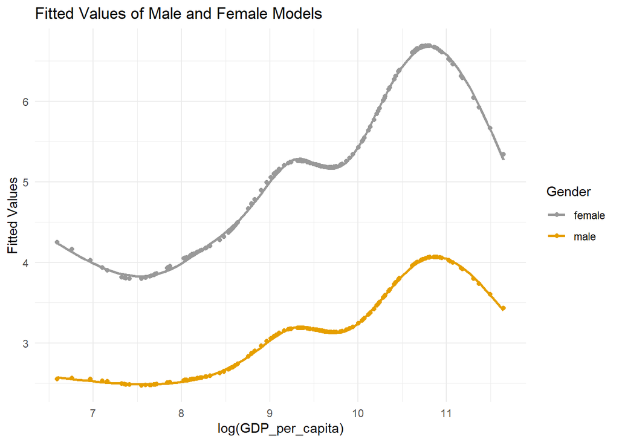

```r
df_long_pred_gam |>
  filter(Year == 2019) |>
  ggplot(aes(x = log_GDP , y = Fitted_Value, color = Gender)) +
  #geom_line(size = 0.6) +
  geom_point() +
  geom_smooth(se = FALSE) +
  labs(title = "Fitted Values of Male and Female Models",
       x = "log(GDP_per_capita)",
       y = "Fitted Values") +
  scale_color_manual(values = cb_palette) +
  theme_minimal()
```

The data analysis did indicate the female anxiety is much significantly larger than males. When we model the male and female anxieties with log gdp and year. The predicted values of the male and female anxiety yet again have a significant difference. So, modeling log gdp alongwith other factors could prove to be a better fit for predicting anxiety levels.